# R Notebook

Nombre: Brndon René Portillo González Proyecto: Fase I

Se cargan algunas de las librerías para iniciar con la exploración, los datos fueron previamente revisados y se tienen 8 fuentes de excel y 8 es SSPS.

```r
install.packages(c("readxl", "dplyr"))
library(readxl)
library(dplyr)
```

```r
ruta <- "C:/Users/Brandon Portillo/Desktop/Nueva carpeta/4to Trimestre/DataMining/ProyectoF1/Fallecidos y lesionados/Excel"

archivos_excel <- list.files(path = ruta, pattern = "\\.xls[x]?$", full.names = TRUE)
print(archivos_excel)
```

```
[1] "C:/Users/Brandon Portillo/Desktop/Nueva carpeta/4to Trimestre/DataMining/ProyectoF1/Fallecidos y lesionados/Excel/2015-Fallecidos y lesionados.xlsx"
[2] "C:/Users/Brandon Portillo/Desktop/Nueva carpeta/4to Trimestre/DataMining/ProyectoF1/Fallecidos y lesionados/Excel/2016-Fallecidos y lesionados.xlsx"
[3] "C:/Users/Brandon Portillo/Desktop/Nueva carpeta/4to Trimestre/DataMining/ProyectoF1/Fallecidos y lesionados/Excel/2017-Fallecidos y lesionados.xlsx"
[4] "C:/Users/Brandon Portillo/Desktop/Nueva carpeta/4to Trimestre/DataMining/ProyectoF1/Fallecidos y lesionados/Excel/2018-Fallecidos y lesionados.xlsx"
[5] "C:/Users/Brandon Portillo/Desktop/Nueva carpeta/4to Trimestre/DataMining/ProyectoF1/Fallecidos y lesionados/Excel/2019-Fallecidos y lesionados.xlsx"
[6] "C:/Users/Brandon Portillo/Desktop/Nueva carpeta/4to Trimestre/DataMining/ProyectoF1/Fallecidos y lesionados/Excel/2020-Fallecidos y lesionados.xlsx"
[7] "C:/Users/Brandon Portillo/Desktop/Nueva carpeta/4to Trimestre/DataMining/ProyectoF1/Fallecidos y lesionados/Excel/2022-Fallecidos y lesionados.xlsx"
[8] "C:/Users/Brandon Portillo/Desktop/Nueva carpeta/4to Trimestre/DataMining/ProyectoF1/Fallecidos y lesionados/Excel/2023-Fallecidos y lesionados.xlsx"
```

Se pueden visualizar las 8 fuentes y a continuación se procede a consolidar las partes. En cada excel algunos tienen 3 hojas pero solo 1 de cada 3 contiene información y todas las fuentes se trata de la Sheet1 la que nos interesa consultar. Además se validó que las columnas se llamaran igual, la llave primaria se llamaba Num_corre, núm_corre y num_corre.Se eliminó la columna area_geo_ocurr ya que solo aparecia en 2 dataset y no contiene mayor segmentación.

```r
lista_datos <- lapply(archivos_excel, function(archivo) {

  # Leer la hoja "Sheet1" (podés cambiar el nombre si tus archivos tienen otra hoja)
  df <- read_excel(archivo, sheet = "Sheet1")

  return(df)
})

# Combinar todos los dataframes en uno solo
datos_excel <- bind_rows(lista_datos)

# Verificar resultado
glimpse(datos_excel)
```

```
Rows: 80,823
Columns: 25
$ núm_corre         <dbl> 1, 2, 3, 4, 5, 6, 7, 8, 9, 10, 11, 12, 13, 14, 15, 16, 17, 18, 19, 20, 21, 22, 23, 24…
$ año_ocu           <dbl> 2015, 2015, 2015, 2015, 2015, 2015, 2015, 2015, 2015, 2015, 2015, 2015, 2015, 2015, 2…
$ mes_ocu           <dbl> 1, 1, 1, 1, 1, 1, 1, 1, 1, 1, 1, 1, 1, 1, 1, 1, 1, 1, 1, 1, 1, 1, 1, 1, 1, 1, 1, 1, 1…
$ día_ocu           <dbl> 1, 1, 1, 1, 1, 1, 1, 1, 1, 1, 1, 1, 1, 1, 1, 1, 1, 1, 1, 1, 1, 1, 1, 2, 2, 2, 2, 2, 2…
$ día_sem_ocu       <dbl> 4, 4, 4, 4, 4, 4, 4, 4, 4, 4, 4, 4, 4, 4, 4, 4, 4, 4, 4, 4, 4, 4, 4, 5, 5, 5, 5, 5, 5…
$ hora_ocu          <dbl> 16, 16, 22, 2, 9, 1, 8, 8, 8, 17, 10, 20, 20, 20, 20, 7, 7, 7, 7, 7, 7, 7, 7, 1, 1, 1…
$ g_hora            <dbl> 3, 3, 4, 1, 2, 1, 2, 2, 2, 3, 2, 4, 4, 4, 4, 2, 2, 2, 2, 2, 2, 2, 2, 1, 1, 2, 4, 4, 1…
$ g_hora_5          <dbl> 2, 2, 3, 1, 1, 1, 1, 1, 1, 2, 1, 3, 3, 3, 3, 1, 1, 1, 1, 1, 1, 1, 1, 1, 1, 1, 3, 3, 1…
$ depto_ocu         <dbl> 1, 1, 1, 1, 1, 1, 1, 1, 1, 1, 6, 6, 6, 6, 6, 11, 11, 11, 11, 11, 11, 11, 11, 1, 1, 1,…
$ mupio_ocu         <dbl> 101, 101, 101, 101, 101, 115, 114, 114, 114, 110, 602, 602, 602, 602, 602, 1101, 1101…
$ zona_ocu          <dbl> 1, 1, 16, 7, 12, 8, 99, 99, 99, 99, 99, 99, 99, 99, 99, 99, 99, 99, 99, 99, 99, 99, 9…
$ sexo_per          <dbl> 1, 2, 1, 1, 1, 1, 1, 1, 2, 1, 1, 1, 1, 1, 1, 1, 1, 1, 1, 1, 1, 2, 1, 1, 1, 1, 1, 1, 1…
$ edad_per          <dbl> 19, 19, 32, 18, 20, 23, 19, 15, 52, 23, 24, 20, 24, 29, 35, 25, 17, 18, 20, 22, 32, 4…
$ mayor_menor       <dbl> 1, 1, 1, 1, 1, 1, 1, 2, 1, 1, 1, 1, 1, 1, 1, 1, 2, 1, 1, 1, 1, 1, 1, 1, 1, 1, 1, 1, 1…
$ g_edad_80ymás     <dbl> 2, 2, 5, 2, 3, 3, 2, 2, 9, 3, 3, 3, 3, 4, 6, 4, 2, 2, 3, 3, 5, 8, 9, 3, 5, 3, 5, 11, …
$ g_edad_60ymás     <dbl> 2, 2, 5, 2, 3, 3, 2, 2, 9, 3, 3, 3, 3, 4, 6, 4, 2, 2, 3, 3, 5, 8, 9, 3, 5, 3, 5, 11, …
$ edad_quinquenales <dbl> 4, 4, 7, 4, 5, 5, 4, 4, 11, 5, 5, 5, 5, 6, 8, 6, 4, 4, 5, 5, 7, 10, 11, 5, 7, 5, 7, 1…
$ fall_les          <dbl> 2, 2, 2, 2, 1, 1, 2, 2, 2, 2, 2, 2, 2, 2, 2, 2, 2, 2, 2, 2, 2, 2, 2, 2, 2, 2, 2, 2, 1…
$ int_o_noint       <dbl> 1, 1, 1, 1, 2, 2, 1, 1, 1, 1, 1, 1, 1, 1, 1, 1, 1, 1, 1, 1, 1, 1, 1, 1, 1, 1, 1, 1, 2…
$ tipo_veh          <dbl> 4, 4, 4, 4, 4, 1, 4, 4, 4, 4, 4, 1, 1, 3, 3, 3, 3, 3, 3, 3, 3, 3, 3, 1, 1, 4, 1, 1, 1…
$ marca_veh         <dbl> 21, 21, 21, 21, 40, 34, 41, 41, 41, 21, 99, 99, 34, 44, 44, 44, 44, 44, 44, 44, 44, 4…
$ color_veh         <dbl> 5, 5, 5, 1, 5, 4, 4, 4, 4, 1, 5, 6, 9, 1, 1, 2, 2, 2, 2, 2, 2, 2, 2, 5, 3, 3, 3, 3, 3…
$ modelo_veh        <dbl> 2011, 2011, 9999, 2000, 9999, 9999, 9999, 9999, 9999, 9999, 9999, 9999, 2001, 2015, 2…
$ g_modelo_veh      <dbl> 5, 5, 6, 4, 6, 6, 6, 6, 6, 6, 6, 6, 4, 5, 5, 4, 4, 4, 4, 4, 4, 4, 4, 6, 6, 6, 4, 4, 6…
$ tipo_eve          <dbl> 1, 1, 1, 1, 2, 2, 3, 3, 3, 1, 3, 1, 1, 1, 1, 3, 3, 3, 3, 3, 3, 3, 3, 1, 1, 1, 1, 1, 2…
```

Ahora se procede a importar la información de los archivos .sav Para ello se instala y se importa la libreria haven

```r
head(datos_excel)
```

| núm_corre | año_ocu | mes_ocu | día_ocu | día_sem_ocu | hora_ocu | g_hora | g_hora_5 | depto_ocu | mupio_ocu | zona_ocu | sexo_per | edad_per | mayor_menor | g_edad_80ymás | g_edad_60ymás | edad_quinquenales | fall_les | int_o_noint | tipo_veh | marca_veh | color_veh | modelo_veh | g_modelo_veh | tipo_eve |
| --- | --- | --- | --- | --- | --- | --- | --- | --- | --- | --- | --- | --- | --- | --- | --- | --- | --- | --- | --- | --- | --- | --- | --- | --- |
| 1 | 2015 | 1 | 1 | 4 | 16 | 3 | 2 | 1 | 101 | 1 | 1 | 19 | 1 | 2 | 2 | 4 | 2 | 1 | 4 | 21 | 5 | 2011 | 5 | 1 |
| 2 | 2015 | 1 | 1 | 4 | 16 | 3 | 2 | 1 | 101 | 1 | 2 | 19 | 1 | 2 | 2 | 4 | 2 | 1 | 4 | 21 | 5 | 2011 | 5 | 1 |
| 3 | 2015 | 1 | 1 | 4 | 22 | 4 | 3 | 1 | 101 | 16 | 1 | 32 | 1 | 5 | 5 | 7 | 2 | 1 | 4 | 21 | 5 | 9999 | 6 | 1 |
| 4 | 2015 | 1 | 1 | 4 | 2 | 1 | 1 | 1 | 101 | 7 | 1 | 18 | 1 | 2 | 2 | 4 | 2 | 1 | 4 | 21 | 1 | 2000 | 4 | 1 |
| 5 | 2015 | 1 | 1 | 4 | 9 | 2 | 1 | 1 | 101 | 12 | 1 | 20 | 1 | 3 | 3 | 5 | 1 | 2 | 4 | 40 | 5 | 9999 | 6 | 2 |
| 6 | 2015 | 1 | 1 | 4 | 1 | 1 | 1 | 1 | 115 | 8 | 1 | 23 | 1 | 3 | 3 | 5 | 1 | 2 | 1 | 34 | 4 | 9999 | 6 | 2 |

```r
install.packages("haven")   # si no lo tenés
library(haven)
```

```r
ruta_spss <- "C:/Users/Brandon Portillo/Desktop/Nueva carpeta/4to Trimestre/DataMining/ProyectoF1/Fallecidos y lesionados/SPSS"

archivos_spss <- list.files(path = ruta_spss, pattern = "\\.sav$", full.names = TRUE)
print(archivos_spss)
```

```
[1] "C:/Users/Brandon Portillo/Desktop/Nueva carpeta/4to Trimestre/DataMining/ProyectoF1/Fallecidos y lesionados/SPSS/2009-Fallesidos.sav"
[2] "C:/Users/Brandon Portillo/Desktop/Nueva carpeta/4to Trimestre/DataMining/ProyectoF1/Fallecidos y lesionados/SPSS/2009-Lesionados.sav"
[3] "C:/Users/Brandon Portillo/Desktop/Nueva carpeta/4to Trimestre/DataMining/ProyectoF1/Fallecidos y lesionados/SPSS/2010-Fallecidos y lesionados.sav"
[4] "C:/Users/Brandon Portillo/Desktop/Nueva carpeta/4to Trimestre/DataMining/ProyectoF1/Fallecidos y lesionados/SPSS/2011-Fallecidos y lesionados.sav"
[5] "C:/Users/Brandon Portillo/Desktop/Nueva carpeta/4to Trimestre/DataMining/ProyectoF1/Fallecidos y lesionados/SPSS/2012-Fallecidos y lesionados.sav"
[6] "C:/Users/Brandon Portillo/Desktop/Nueva carpeta/4to Trimestre/DataMining/ProyectoF1/Fallecidos y lesionados/SPSS/2013-Fallecidos y lesionados.sav"
[7] "C:/Users/Brandon Portillo/Desktop/Nueva carpeta/4to Trimestre/DataMining/ProyectoF1/Fallecidos y lesionados/SPSS/2014-Fallecidos y lesionados.sav"
[8] "C:/Users/Brandon Portillo/Desktop/Nueva carpeta/4to Trimestre/DataMining/ProyectoF1/Fallecidos y lesionados/SPSS/2021-Fallecidos y lesionados.sav"
```

```r
install.packages("haven")   # si no lo tenés
library(haven)
```

Se visualiza el contenido de los encabezados

```r
names(lista_spss[[1]])
```

```
 [1] "num_hecho"   "dia_ocu"     "mes_ocu"     "dia_sem_ocu" "hora_ocu"    "depto_ocu"   "areag_ocu"
 [8] "sexo_pil"    "edad_fall"   "g_edad"      "edad_m1"     "tipo_vehi"   "color_vehi"  "modelo_vehi"
[15] "causa_acc"
```

Se visualizan los primeros datos…

```r
head(lista_spss[[1]])
```

| num_hecho | dia_ocu | mes_ocu | dia_sem_ocu | hora_ocu | depto_ocu | areag_ocu | sexo_pil | edad_fall | g_edad | edad_m1 | tipo_vehi | color_vehi | modelo_vehi | causa_acc |
| --- | --- | --- | --- | --- | --- | --- | --- | --- | --- | --- | --- | --- | --- | --- |
| 864 | 25 | 12 | 5 | 999 | 1 | 1 | 1 | 22 | 5 | 1 | 4 | 1 | 9999 | 1 |
| 656 | 25 | 8 | 2 | 0 | 16 | 2 | 1 | 43 | 7 | 1 | 3 | 1 | 1986 | 4 |
| 116 | 19 | 2 | 4 | 0 | 14 | 2 | 2 | 1 | 1 | 2 | 3 | 5 | 1987 | 3 |
| 170 | 7 | 3 | 6 | 0 | 5 | 2 | 1 | 28 | 6 | 1 | 4 | 1 | 1988 | 2 |
| 291 | 19 | 4 | 7 | 0 | 19 | 1 | 1 | 17 | 4 | 2 | 4 | 5 | 1991 | 1 |
| 392 | 4 | 6 | 4 | 0 | 17 | 1 | 2 | 34 | 6 | 1 | 3 | 3 | 1994 | 1 |

Se consolidan los SSPS

```r
nombres_spss <- lapply(archivos_spss, function(archivo) {
  df <- read_sav(archivo)
  names(df)
})

for (i in seq_along(archivos_spss)) {
  cat("\n Archivo:", basename(archivos_spss[i]), "\n")
  print(nombres_spss[[i]])
}
```

```
 Archivo: 2009-Fallesidos.sav
 [1] "num_hecho"   "dia_ocu"     "mes_ocu"     "dia_sem_ocu" "hora_ocu"    "depto_ocu"   "areag_ocu"
 [8] "sexo_pil"    "edad_fall"   "g_edad"      "edad_m1"     "tipo_vehi"   "color_vehi"  "modelo_vehi"
[15] "causa_acc"

 Archivo: 2009-Lesionados.sav
 [1] "num_hecho"   "dia_ocu"     "mes_ocu"     "dia_sem_ocu" "hora_ocu"    "depto_ocu"   "areag_ocu"
 [8] "sexo_les"    "edad_les"    "g_edad"      "edad_m1"     "tipo_vehi"   "color_vehi"  "modelo_vehi"
[15] "causa_acc"

 Archivo: 2010-Fallecidos y lesionados.sav
 [1] "dia_ocu"       "mes_ocu"       "dia_sem_ocu"   "hora_ocu"      "depto_ocu"     "areag_ocu"
 [7] "zona_ocu"      "sexo_fall_les" "edad_fall_les" "g_edad"        "lesio_fall"    "tipo_vehi"
[13] "Causa_acc"

 Archivo: 2011-Fallecidos y lesionados.sav
 [1] "num_hecho"     "dia_ocu"       "mes_ocu"       "dia_sem_ocu"   "hora_ocu"      "depto_ocu"
 [7] "muni_ocu"      "areag_ocu"     "zona_ocu"      "sexo_pil"      "edad_pil"      "g_edad"
[13] "edad_m1"       "condicion_pil" "tipo_vehi"     "marca_vehi"    "color_vehi"    "modelo_vehi"
[19] "causa_acc"

 Archivo: 2012-Fallecidos y lesionados.sav
 [1] "num_hecho"        "dia_ocu"          "mes_ocu"          "dia_sem_ocu"      "hora_ocu"
 [6] "depto_ocu"        "mupio_ocu"        "areag_ocu"        "zona_ocu"         "sexo_fall_les"
[11] "edad_fall_les"    "edad_m1"          "g_edad_fall_les"  "estado_implicado" "tipo_vehi"
[16] "color_vehi"       "casusa_acc"

 Archivo: 2013-Fallecidos y lesionados.sav
 [1] "num_hecho"             "dia_ocu"               "mes_ocu"               "dia_sem_ocu"
 [5] "hora_ocu"              "g_hora"                "depto_ocu"             "mupio_ocu"
 [9] "areag_ocu"             "zona_ocu"              "sexo_pil"              "edad_pil"
[13] "g_edad_2"              "mayor_menor"           "tipo_veh"              "color_veh"
[17] "modelo_veh"            "causa_acc"             "marca_veh"             "g_edad"
[21] "Fallecidos_Lesionados" "Otro_g_edad_fall_les"

 Archivo: 2014-Fallecidos y lesionados.sav
 [1] "num_correlativo"   "num_corre"         "corre_base"        "día_ocu"           "día_sem_ocu"
 [6] "hora_ocu"          "g_hora"            "mes_ocu"           "depto_ocu"         "mupio_ocu"
[11] "zona_ocu"          "área_geo_ocu"      "sexo_víc"          "edad_víc"          "g_edad"
[16] "mayor_menor"       "fall_les"          "tipo_veh"          "modelo_veh"        "color_veh"
[21] "marca_veh"         "tipo_eve"          "edad_quinquenales"

 Archivo: 2021-Fallecidos y lesionados.sav
 [1] "núm_corre"         "año_ocu"           "día_ocu"           "hora_ocu"          "g_hora"
 [6] "g_hora_5"          "mes_ocu"           "día_sem_ocu"       "depto_ocu"         "mupio_ocu"
[11] "zona_ocu"          "zona_ciudad"       "sexo_per"          "edad_per"          "g_edad_80ymás"
[16] "g_edad_60ymás"     "edad_quinquenales" "mayor_menor"       "tipo_veh"          "marca_veh"
[21] "color_veh"         "modelo_veh"        "g_modelo_veh"      "tipo_eve"          "fall_les"
[26] "int_o_noint"
```

De los archivos SPSS solo se considera el del año 2021 ya que los demás están incompletos porque les faltan muchas variables a todos en diferentes puntos y eso no favorece nuestro proceso de mineria de datos.

```r
ruta_archivo <- "C:/Users/Brandon Portillo/Desktop/Nueva carpeta/4to Trimestre/DataMining/ProyectoF1/Fallecidos y lesionados/SPSS/2021-Fallecidos y lesionados.sav"

# Leer el archivo
fallecidos_2021 <- read_sav(ruta_archivo)
head(fallecidos_2021)
```

| núm_corre | año_ocu | día_ocu | hora_ocu | g_hora | g_hora_5 | mes_ocu | día_sem_ocu | depto_ocu | mupio_ocu | zona_ocu | zona_ciudad | sexo_per | edad_per | g_edad_80ymás | g_edad_60ymás | edad_quinquenales | mayor_menor | tipo_veh | marca_veh | color_veh | modelo_veh | g_modelo_veh | tipo_eve | fall_les | int_o_noint |
| --- | --- | --- | --- | --- | --- | --- | --- | --- | --- | --- | --- | --- | --- | --- | --- | --- | --- | --- | --- | --- | --- | --- | --- | --- | --- |
| 1 | 2021 | 1 | 7 | 2 | 1 | 1 | 5 | 1 | 101 | 8 | 8 | 1 | 23 | 3 | 3 | 5 | 1 | 4 | 67 | 4 | 2020 | 6 | 6 | 1 | 2 |
| 2 | 2021 | 1 | 9 | 2 | 1 | 1 | 5 | 1 | 101 | 18 | 18 | 1 | 25 | 4 | 4 | 6 | 1 | 4 | 20 | 1 | 9999 | 99 | 1 | 2 | 1 |
| 3 | 2021 | 1 | 5 | 1 | 1 | 1 | 5 | 1 | 101 | 21 | 21 | 1 | 35 | 6 | 6 | 8 | 1 | 4 | 100 | 5 | 9999 | 99 | 6 | 1 | 2 |
| 4 | 2021 | 1 | 2 | 1 | 1 | 1 | 5 | 1 | 115 | 99 | 99 | 1 | 20 | 3 | 3 | 5 | 1 | 4 | 3 | 5 | 9999 | 99 | 1 | 1 | 2 |
| 5 | 2021 | 1 | 19 | 4 | 3 | 1 | 5 | 1 | 114 | 99 | 99 | 1 | 40 | 7 | 7 | 9 | 1 | 4 | 18 | 7 | 2015 | 5 | 1 | 2 | 1 |
| 6 | 2021 | 1 | 19 | 4 | 3 | 1 | 5 | 1 | 114 | 99 | 99 | 2 | 36 | 6 | 6 | 8 | 1 | 4 | 18 | 7 | 2015 | 5 | 1 | 2 | 1 |

```r
NA
```

```r
fallecidos_2021 <- fallecidos_2021 %>%
  select(-zona_ciudad)
head(fallecidos_2021)
```

| núm_corre | año_ocu | día_ocu | hora_ocu | g_hora | g_hora_5 | mes_ocu | día_sem_ocu | depto_ocu | mupio_ocu | zona_ocu | sexo_per | edad_per | g_edad_80ymás | g_edad_60ymás | edad_quinquenales | mayor_menor | tipo_veh | marca_veh | color_veh | modelo_veh | g_modelo_veh | tipo_eve | fall_les | int_o_noint |
| --- | --- | --- | --- | --- | --- | --- | --- | --- | --- | --- | --- | --- | --- | --- | --- | --- | --- | --- | --- | --- | --- | --- | --- | --- |
| 1 | 2021 | 1 | 7 | 2 | 1 | 1 | 5 | 1 | 101 | 8 | 1 | 23 | 3 | 3 | 5 | 1 | 4 | 67 | 4 | 2020 | 6 | 6 | 1 | 2 |
| 2 | 2021 | 1 | 9 | 2 | 1 | 1 | 5 | 1 | 101 | 18 | 1 | 25 | 4 | 4 | 6 | 1 | 4 | 20 | 1 | 9999 | 99 | 1 | 2 | 1 |
| 3 | 2021 | 1 | 5 | 1 | 1 | 1 | 5 | 1 | 101 | 21 | 1 | 35 | 6 | 6 | 8 | 1 | 4 | 100 | 5 | 9999 | 99 | 6 | 1 | 2 |
| 4 | 2021 | 1 | 2 | 1 | 1 | 1 | 5 | 1 | 115 | 99 | 1 | 20 | 3 | 3 | 5 | 1 | 4 | 3 | 5 | 9999 | 99 | 1 | 1 | 2 |
| 5 | 2021 | 1 | 19 | 4 | 3 | 1 | 5 | 1 | 114 | 99 | 1 | 40 | 7 | 7 | 9 | 1 | 4 | 18 | 7 | 2015 | 5 | 1 | 2 | 1 |
| 6 | 2021 | 1 | 19 | 4 | 3 | 1 | 5 | 1 | 114 | 99 | 2 | 36 | 6 | 6 | 8 | 1 | 4 | 18 | 7 | 2015 | 5 | 1 | 2 | 1 |

Ahora se tienen también 25 variables para analizar, se consolidará esta información a los 8 datasets de excel. La columna que se ignoró fue la de zona_ciudad ya que está redundante y no es comun respecto al otro dataset.

Se procede a explorar que columnas coinciden entonces

```r
columnas_comunes <- intersect(names(datos_excel), names(fallecidos_2021))

length(columnas_comunes)    # cuántas columnas coinciden
```

```
[1] 25
```

```r
columnas_comunes            # nombres de las columnas comunes
```

```
 [1] "núm_corre"         "año_ocu"           "mes_ocu"           "día_ocu"           "día_sem_ocu"
 [6] "hora_ocu"          "g_hora"            "g_hora_5"          "depto_ocu"         "mupio_ocu"
[11] "zona_ocu"          "sexo_per"          "edad_per"          "mayor_menor"       "g_edad_80ymás"
[16] "g_edad_60ymás"     "edad_quinquenales" "fall_les"          "int_o_noint"       "tipo_veh"
[21] "marca_veh"         "color_veh"         "modelo_veh"        "g_modelo_veh"      "tipo_eve"
```

```r
datos_excel_comunes <- datos_excel[, columnas_comunes, drop = FALSE]
fallecidos_2021_comunes <- fallecidos_2021[, columnas_comunes, drop = FALSE]

# Se unen datasets
datos_consolidados <- bind_rows(datos_excel_comunes, fallecidos_2021_comunes)
head(datos_consolidados)
```

| núm_corre | año_ocu | mes_ocu | día_ocu | día_sem_ocu | hora_ocu | g_hora | g_hora_5 | depto_ocu | mupio_ocu | zona_ocu | sexo_per | edad_per | mayor_menor | g_edad_80ymás | g_edad_60ymás | edad_quinquenales | fall_les | int_o_noint | tipo_veh | marca_veh | color_veh | modelo_veh | g_modelo_veh | tipo_eve |
| --- | --- | --- | --- | --- | --- | --- | --- | --- | --- | --- | --- | --- | --- | --- | --- | --- | --- | --- | --- | --- | --- | --- | --- | --- |
| 1 | 2015 | 1 | 1 | 4 | 16 | 3 | 2 | 1 | 101 | 1 | 1 | 19 | 1 | 2 | 2 | 4 | 2 | 1 | 4 | 21 | 5 | 2011 | 5 | 1 |
| 2 | 2015 | 1 | 1 | 4 | 16 | 3 | 2 | 1 | 101 | 1 | 2 | 19 | 1 | 2 | 2 | 4 | 2 | 1 | 4 | 21 | 5 | 2011 | 5 | 1 |
| 3 | 2015 | 1 | 1 | 4 | 22 | 4 | 3 | 1 | 101 | 16 | 1 | 32 | 1 | 5 | 5 | 7 | 2 | 1 | 4 | 21 | 5 | 9999 | 6 | 1 |
| 4 | 2015 | 1 | 1 | 4 | 2 | 1 | 1 | 1 | 101 | 7 | 1 | 18 | 1 | 2 | 2 | 4 | 2 | 1 | 4 | 21 | 1 | 2000 | 4 | 1 |
| 5 | 2015 | 1 | 1 | 4 | 9 | 2 | 1 | 1 | 101 | 12 | 1 | 20 | 1 | 3 | 3 | 5 | 1 | 2 | 4 | 40 | 5 | 9999 | 6 | 2 |
| 6 | 2015 | 1 | 1 | 4 | 1 | 1 | 1 | 1 | 115 | 8 | 1 | 23 | 1 | 3 | 3 | 5 | 1 | 2 | 1 | 34 | 4 | 9999 | 6 | 2 |

```r
dim(datos_consolidados)
```

```
[1] 91367    25
```

Se procede a trabajar con los primeros modelos para analisis de los datos integrando la información de accidentes de transito de los años 2015 a 2023 respectivamente lo que corresponde a 9 años de registros históricos reportados por la PNC.

Acontinuación se procede a encontrar patrones mediante APRIORI

```r
library(arules)
#Se utilizan solo 10 columnas de las 25.

data_apriori <- datos_consolidados[, c("año_ocu", "mes_ocu","día_ocu","depto_ocu", "sexo_per", "edad_per", "fall_les", "tipo_veh", "modelo_veh","tipo_eve")]
#Se eliminan los valores desconocidos para validar los patrones sin ruido en las reglas

data_apriori <- subset(data_apriori, fall_les != 9 & tipo_eve != 99 & sexo_per != 9 & edad_per != 999)
dim(data_apriori)
```

```
[1] 84172    10
```

```r
datos_trans <- as(data_apriori, "transactions")
reglas_generales <- apriori(datos_trans, parameter = list(support=0.2, confidence = 0.5))
```

```
Apriori

Parameter specification:
```

|  | confidence | minval | smax | arem | aval | originalSupport | maxtime | support | minlen | maxlen | target | ext |
| --- | --- | --- | --- | --- | --- | --- | --- | --- | --- | --- | --- | --- |
|  | 0.5 | 0.1 | 1 | none | FALSE | TRUE | 5 | 0.2 | 1 | 10 | rules | TRUE |

```
Algorithmic control:
```

|  | filter | tree | heap | memopt | load | sort | verbose |
| --- | --- | --- | --- | --- | --- | --- | --- |
|  | 0.1 | TRUE | TRUE | FALSE | TRUE | 2 | TRUE |

```
Absolute minimum support count: 16834

set item appearances ...[0 item(s)] done [0.00s].
set transactions ...[22 item(s), 84172 transaction(s)] done [0.02s].
sorting and recoding items ... [21 item(s)] done [0.00s].
creating transaction tree ... done [0.02s].
checking subsets of size 1 2 3 4 5 6 done [0.00s].
writing ... [764 rule(s)] done [0.00s].
creating S4 object  ... done [0.00s].
```

```r
length(reglas_generales)
```

```
[1] 764
```

```r
# De las 764 reglas de todo el dataset tenemos ya las 75 mas sobresalientes determinando que segun lift mayor que 1 contienen más correlacion con los hechos de transito.

reglas_ordenadas <- sort(reglas_generales, by = "lift", decreasing = TRUE)
inspect(head(reglas_ordenadas, 75))
```

```
     lhs                               rhs                  support confidence  coverage     lift count
[1]  {edad_per=[23,34),
      fall_les=[2,3]}               => {tipo_eve=[1,4)}   0.2004942  0.7468248 0.2684622 1.120750 16876
[2]  {edad_per=[23,34),
      fall_les=[2,3],
      modelo_veh=[1.94e+03,1e+04]}  => {tipo_eve=[1,4)}   0.2004942  0.7468248 0.2684622 1.120750 16876
[3]  {sexo_per=[1,2],
      edad_per=[23,34),
      fall_les=[2,3]}               => {tipo_eve=[1,4)}   0.2004942  0.7468248 0.2684622 1.120750 16876
[4]  {sexo_per=[1,2],
      edad_per=[23,34),
      fall_les=[2,3],
      modelo_veh=[1.94e+03,1e+04]}  => {tipo_eve=[1,4)}   0.2004942  0.7468248 0.2684622 1.120750 16876
[5]  {edad_per=[23,34)}             => {tipo_eve=[1,4)}   0.2350307  0.7210862 0.3259397 1.082124 19783
[6]  {edad_per=[23,34),
      modelo_veh=[1.94e+03,1e+04]}  => {tipo_eve=[1,4)}   0.2350307  0.7210862 0.3259397 1.082124 19783
[7]  {sexo_per=[1,2],
      edad_per=[23,34)}             => {tipo_eve=[1,4)}   0.2350307  0.7210862 0.3259397 1.082124 19783
[8]  {sexo_per=[1,2],
      edad_per=[23,34),
      modelo_veh=[1.94e+03,1e+04]}  => {tipo_eve=[1,4)}   0.2350307  0.7210862 0.3259397 1.082124 19783
[9]  {edad_per=[0,23),
      tipo_eve=[1,4)}               => {fall_les=[2,3]}   0.2004823  0.8923378 0.2246709 1.081760 16875
[10] {edad_per=[0,23),
      modelo_veh=[1.94e+03,1e+04],
      tipo_eve=[1,4)}               => {fall_les=[2,3]}   0.2004823  0.8923378 0.2246709 1.081760 16875
[11] {sexo_per=[1,2],
      edad_per=[0,23),
      tipo_eve=[1,4)}               => {fall_les=[2,3]}   0.2004823  0.8923378 0.2246709 1.081760 16875
[12] {sexo_per=[1,2],
      edad_per=[0,23),
      modelo_veh=[1.94e+03,1e+04],
      tipo_eve=[1,4)}               => {fall_les=[2,3]}   0.2004823  0.8923378 0.2246709 1.081760 16875
[13] {edad_per=[23,34)}             => {tipo_veh=[4,99]}  0.2438222  0.7480590 0.3259397 1.068391 20523
[14] {edad_per=[23,34),
      modelo_veh=[1.94e+03,1e+04]}  => {tipo_veh=[4,99]}  0.2438222  0.7480590 0.3259397 1.068391 20523
[15] {sexo_per=[1,2],
      edad_per=[23,34)}             => {tipo_veh=[4,99]}  0.2438222  0.7480590 0.3259397 1.068391 20523
[16] {sexo_per=[1,2],
      edad_per=[23,34),
```

[output cut: 154 more lines]

```
      tipo_eve=[1,4)}               => {fall_les=[2,3]}   0.2420757  0.8656273 0.2796536 1.049380 20376
[70] {año_ocu=[2017,2021),
      modelo_veh=[1.94e+03,1e+04],
      tipo_eve=[1,4)}               => {fall_les=[2,3]}   0.2420757  0.8656273 0.2796536 1.049380 20376
[71] {año_ocu=[2017,2021),
      sexo_per=[1,2],
      tipo_eve=[1,4)}               => {fall_les=[2,3]}   0.2420757  0.8656273 0.2796536 1.049380 20376
[72] {año_ocu=[2017,2021),
      sexo_per=[1,2],
      modelo_veh=[1.94e+03,1e+04],
      tipo_eve=[1,4)}               => {fall_les=[2,3]}   0.2420757  0.8656273 0.2796536 1.049380 20376
[73] {tipo_eve=[1,4)}               => {fall_les=[2,3]}   0.5739319  0.8612919 0.6663617 1.044124 48309
[74] {fall_les=[2,3]}               => {tipo_eve=[1,4)}   0.5739319  0.6957643 0.8248943 1.044124 48309
[75] {modelo_veh=[1.94e+03,1e+04],
      tipo_eve=[1,4)}               => {fall_les=[2,3]}   0.5739319  0.8612919 0.6663617 1.044124 48309
```

Otro hecho que no sucede que no hay reglas fuertes que implequen accidentes o lesiones para el tipo de evento de caidas, por ende se observa que si los tipos de evento son colisiones choques o vuelcos entonces hay mayor probilidad de lesion o fallecimiento.

```r
install.packages("arulesViz")
library(arulesViz)
```

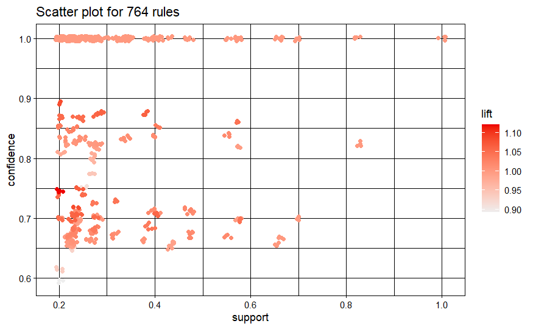

```r
# Se grafica la dispersión soporte vs confianza.
plot(reglas_generales, measure = c("support", "confidence"), shading = "lift")
```

```
Available control parameters (with default values):
layout   =  stress
circular     =  FALSE
ggraphdots   =  NULL
edges    =  <environment>
nodes    =  <environment>
nodetext     =  <environment>
colors   =  c("#EE0000FF", "#EEEEEEFF")
engine   =  ggplot2
max  =  100
verbose  =  FALSE
```

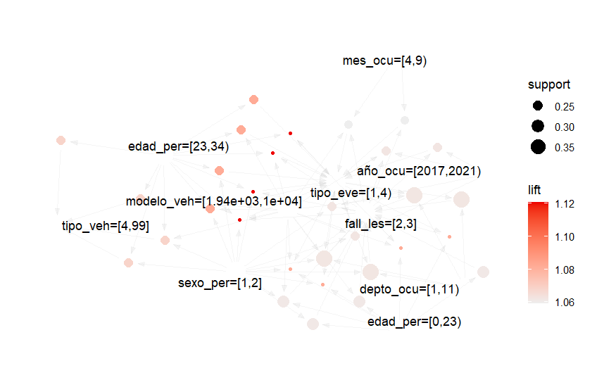

```r
# Visualizando las 30 reglas mas importantes.
plot(head(sort(reglas_generales, by="lift"), 30), method = "graph", control = list(type="items"))
```

```r
data_apriori_gua <- subset(
  data_apriori,
  fall_les != 9 & tipo_eve != 99 & sexo_per != 9 & edad_per != 999 & depto_ocu == 1
)
datos_filtrados_gua <- data_apriori_gua[, -c(4,7,9)]
# Calcular número de valores únicos por columna
num_valores_unicos <- sapply(datos_filtrados_gua, function(x) length(unique(x)))

# Imprimir de forma legible
for (col in names(num_valores_unicos)) {
  cat(col, ":", num_valores_unicos[col], "\n")
}
```

```
año_ocu : 9
mes_ocu : 12
día_ocu : 31
sexo_per : 2
edad_per : 99
tipo_veh : 19
tipo_eve : 8
```

```r
datos_trans_gua <- as(datos_filtrados_gua, "transactions")

reglas_gua <- apriori(datos_trans_gua, parameter = list(support=0.2, confidence = 0.5))
```

```
Apriori

Parameter specification:
```

|  | confidence | minval | smax | arem | aval | originalSupport | maxtime | support | minlen | maxlen | target | ext |
| --- | --- | --- | --- | --- | --- | --- | --- | --- | --- | --- | --- | --- |
|  | 0.5 | 0.1 | 1 | none | FALSE | TRUE | 5 | 0.2 | 1 | 10 | rules | TRUE |

```
Algorithmic control:
```

|  | filter | tree | heap | memopt | load | sort | verbose |
| --- | --- | --- | --- | --- | --- | --- | --- |
|  | 0.1 | TRUE | TRUE | FALSE | TRUE | 2 | TRUE |

```
Absolute minimum support count: 5743

set item appearances ...[0 item(s)] done [0.00s].
set transactions ...[17 item(s), 28716 transaction(s)] done [0.01s].
sorting and recoding items ... [17 item(s)] done [0.00s].
creating transaction tree ... done [0.01s].
checking subsets of size 1 2 3 4 done [0.00s].
writing ... [94 rule(s)] done [0.00s].
creating S4 object  ... done [0.00s].
```

```r
inspect(reglas_gua[0:94])
```

|  | lhs |  | rhs | support | confidence | coverage | lift | count |
| --- | --- | --- | --- | --- | --- | --- | --- | --- |
| [1] | {} | => | {tipo_eve=[1,5)} | 0.6460858 | 0.6460858 | 1.0000000 | 1.0000000 | 18553 |
| [2] | {} | => | {tipo_veh=[4,99]} | 0.7400752 | 0.7400752 | 1.0000000 | 1.0000000 | 21252 |
| [3] | {} | => | {sexo_per=[1,2]} | 1.0000000 | 1.0000000 | 1.0000000 | 1.0000000 | 28716 |
| [4] | {tipo_veh=[1,4)} | => | {sexo_per=[1,2]} | 0.2599248 | 1.0000000 | 0.2599248 | 1.0000000 | 7464 |
| [5] | {edad_per=[0,23)} | => | {tipo_veh=[4,99]} | 0.2189372 | 0.7579265 | 0.2888634 | 1.0241208 | 6287 |
| [6] | {edad_per=[0,23)} | => | {sexo_per=[1,2]} | 0.2888634 | 1.0000000 | 0.2888634 | 1.0000000 | 8295 |
| [7] | {año_ocu=[2015,2018)} | => | {sexo_per=[1,2]} | 0.2906045 | 1.0000000 | 0.2906045 | 1.0000000 | 8345 |
| [8] | {mes_ocu=[5,9)} | => | {tipo_eve=[1,5)} | 0.2080722 | 0.6565934 | 0.3168965 | 1.0162635 | 5975 |
| [9] | {mes_ocu=[5,9)} | => | {tipo_veh=[4,99]} | 0.2366277 | 0.7467033 | 0.3168965 | 1.0089560 | 6795 |
| [10] | {mes_ocu=[5,9)} | => | {sexo_per=[1,2]} | 0.3168965 | 1.0000000 | 0.3168965 | 1.0000000 | 9100 |

[output cut: 84 more lines]

```r
NA
```

```r
data_fp <- datos_consolidados[, c("año_ocu", "mes_ocu","día_ocu","depto_ocu", "sexo_per", "edad_per", "fall_les", "tipo_veh","tipo_eve")]
#Se eliminan los valores desconocidos para validar los patrones sin ruido en las reglas

data_fp <- subset(data_fp, fall_les != 9 & tipo_eve != 99 & sexo_per != 9 & edad_per != 999)
data_fp_gua <- subset(
  data_fp,
  fall_les != 9 & tipo_eve != 99 & sexo_per != 9 & edad_per != 999 & depto_ocu == 1
)
datos_fp_gua <- data_fp_gua[, -4]

datos_trans_fp_gua <- as(datos_fp_gua, "transactions")


reglas_fp_gua <- fim4r(datos_trans_fp_gua, method="fpgrowth", target ="rules", supp =.2, conf=.5)
```

```
fim4r.fpgrowth

Parameter specification:
```

|  | supp | conf | target | report |
| --- | --- | --- | --- | --- |
|  | 20 | 50 | rules | scl |

```
Data size: 28716 transactions and 19 items
Result: 226 rules
```

```r
rf <- as(reglas_fp_gua, "data.frame")
rf
```

|  | rules | support | confidence | lift | count |
| --- | --- | --- | --- | --- | --- |
| 1 | {} => {sexo_per=[1,2]} | 1.0000000 | 1.0000000 | 1.0000000 | 28716 |
| 2 | {fall_les=[2,3]} => {sexo_per=[1,2]} | 0.8769327 | 1.0000000 | 1.0000000 | 25182 |
| 3 | {sexo_per=[1,2]} => {fall_les=[2,3]} | 0.8769327 | 0.8769327 | 1.0000000 | 25182 |
| 4 | {} => {fall_les=[2,3]} | 0.8769327 | 0.8769327 | 1.0000000 | 25182 |
| 5 | {tipo_veh=[4,99]} => {sexo_per=[1,2]} | 0.7400752 | 1.0000000 | 1.0000000 | 21252 |
| 6 | {sexo_per=[1,2]} => {tipo_veh=[4,99]} | 0.7400752 | 0.7400752 | 1.0000000 | 21252 |
| 7 | {fall_les=[2,3],tipo_veh=[4,99]} => {sexo_per=[1,2]} | 0.6469564 | 1.0000000 | 1.0000000 | 18578 |
| 8 | {sexo_per=[1,2],tipo_veh=[4,99]} => {fall_les=[2,3]} | 0.6469564 | 0.8741765 | 0.9968570 | 18578 |
| 9 | {sexo_per=[1,2],fall_les=[2,3]} => {tipo_veh=[4,99]} | 0.6469564 | 0.7377492 | 0.9968570 | 18578 |
| 10 | {tipo_veh=[4,99]} => {fall_les=[2,3]} | 0.6469564 | 0.8741765 | 0.9968570 | 18578 |

[output cut: 216 more lines]

```r
data_fp <- datos_consolidados[, c("año_ocu", "mes_ocu","día_ocu","depto_ocu", "sexo_per", "edad_per", "fall_les", "tipo_veh","tipo_eve")]
#Se eliminan los valores desconocidos para validar los patrones sin ruido en las reglas

data_fp <- subset(data_fp, fall_les != 9 & tipo_eve != 99 & sexo_per != 9 & edad_per != 999)
data_fp_gua_fall <- subset(
  data_fp,
  fall_les != 9 & tipo_eve != 99 & sexo_per != 9 & edad_per != 999 & depto_ocu == 1 & fall_les==2
)
datos_fp_gua_fall <- data_fp_gua_fall[, -c(4,7)]

datos_trans_fp_gua_fall <- as(datos_fp_gua_fall, "transactions")


reglas_fp_gua_fall <- fim4r(datos_trans_fp_gua_fall, method="fpgrowth", target ="rules", supp =.2, conf=.5)
```

```
fim4r.fpgrowth

Parameter specification:
```

|  | supp | conf | target | report |
| --- | --- | --- | --- | --- |
|  | 20 | 50 | rules | scl |

```
Data size: 25180 transactions and 17 items
Result: 100 rules
```

```r
rf_fall <- as(reglas_fp_gua_fall, "data.frame")
rf_fall
```

|  | rules | support | confidence | lift | count |
| --- | --- | --- | --- | --- | --- |
| 1 | {} => {sexo_per=[1,2]} | 1.0000000 | 1.0000000 | 1.0000000 | 25180 |
| 2 | {tipo_veh=[4,99]} => {sexo_per=[1,2]} | 0.7377681 | 1.0000000 | 1.0000000 | 18577 |
| 3 | {sexo_per=[1,2]} => {tipo_veh=[4,99]} | 0.7377681 | 0.7377681 | 1.0000000 | 18577 |
| 4 | {} => {tipo_veh=[4,99]} | 0.7377681 | 0.7377681 | 1.0000000 | 18577 |
| 5 | {tipo_eve=[1,5)} => {sexo_per=[1,2]} | 0.6660445 | 1.0000000 | 1.0000000 | 16771 |
| 6 | {sexo_per=[1,2]} => {tipo_eve=[1,5)} | 0.6660445 | 0.6660445 | 1.0000000 | 16771 |
| 7 | {tipo_veh=[4,99],tipo_eve=[1,5)} => {sexo_per=[1,2]} | 0.5151708 | 1.0000000 | 1.0000000 | 12972 |
| 8 | {sexo_per=[1,2],tipo_eve=[1,5)} => {tipo_veh=[4,99]} | 0.5151708 | 0.7734780 | 1.0484027 | 12972 |
| 9 | {sexo_per=[1,2],tipo_veh=[4,99]} => {tipo_eve=[1,5)} | 0.5151708 | 0.6982828 | 1.0484027 | 12972 |
| 10 | {tipo_eve=[1,5)} => {tipo_veh=[4,99]} | 0.5151708 | 0.7734780 | 1.0484027 | 12972 |

[output cut: 90 more lines]

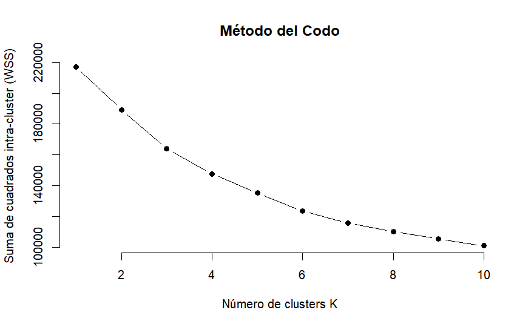

```r
library(ggplot2)

data_fp <- datos_consolidados[, c("año_ocu", "mes_ocu","día_ocu","depto_ocu", "sexo_per", "edad_per", "fall_les", "tipo_veh","tipo_eve")]
#Se eliminan los valores desconocidos para validar los patrones sin ruido en las reglas

data_fp <- subset(data_fp, fall_les != 9 & tipo_eve != 99 & sexo_per != 9 & tipo_veh!=99 & edad_per != 999)
data_fp_gua <- subset(
  data_fp,
  fall_les != 9 & tipo_eve != 99 & sexo_per != 9 & edad_per != 999 & depto_ocu == 1
)
data_fp_gua <- data_fp_gua[, -4]


data_fp_scaled <- scale(data_fp_gua)

wss <- vector()
for (k in 1:10) {
  kmeans_model <- kmeans(data_fp_scaled, centers = k, nstart = 25)
  wss[k] <- kmeans_model$tot.withinss
}

plot(1:10, wss, type="b", pch=19, frame=FALSE,
     xlab="Número de clusters K",
     ylab="Suma de cuadrados intra-cluster (WSS)",
     main="Método del Codo")
```

```r
NA
NA
```

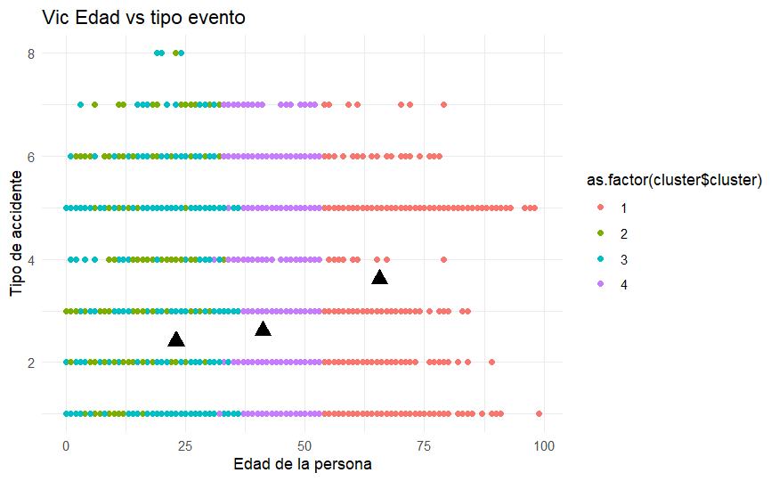

```r
cluster <- kmeans(data_fp_gua, centers = 4)
ggplot(data_fp_gua, aes(x = edad_per, y = tipo_eve, color = as.factor(cluster$cluster))) +
  geom_point() +
  geom_point(data = as.data.frame(cluster$centers),
             aes(x = edad_per, y = tipo_eve),
             color = "black", size = 4, shape = 17) +
  labs(title = "Vic Edad vs tipo evento") +
  theme_minimal()
```

```r
NA
NA
```

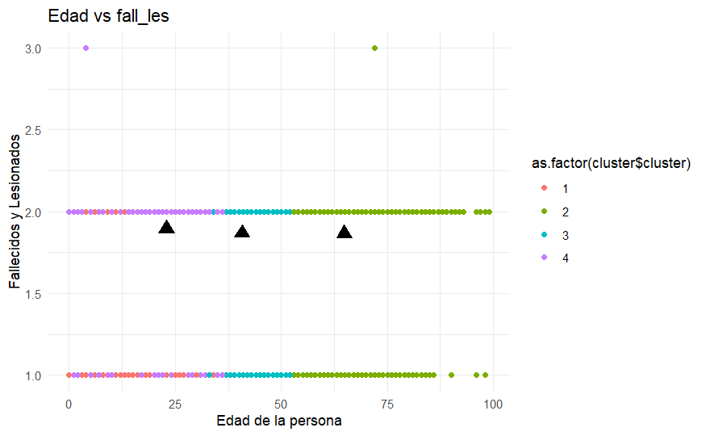

```r
cluster <- kmeans(data_fp_gua, centers = 4)
ggplot(data_fp_gua, aes(x = edad_per, y = fall_les, color = as.factor(cluster$cluster))) +
  geom_point() +
  geom_point(data = as.data.frame(cluster$centers),
             aes(x = edad_per, y = fall_les),
             color = "black", size = 4, shape = 17) +
  labs(title = "Edad vs fall_les") +
  theme_minimal()
```

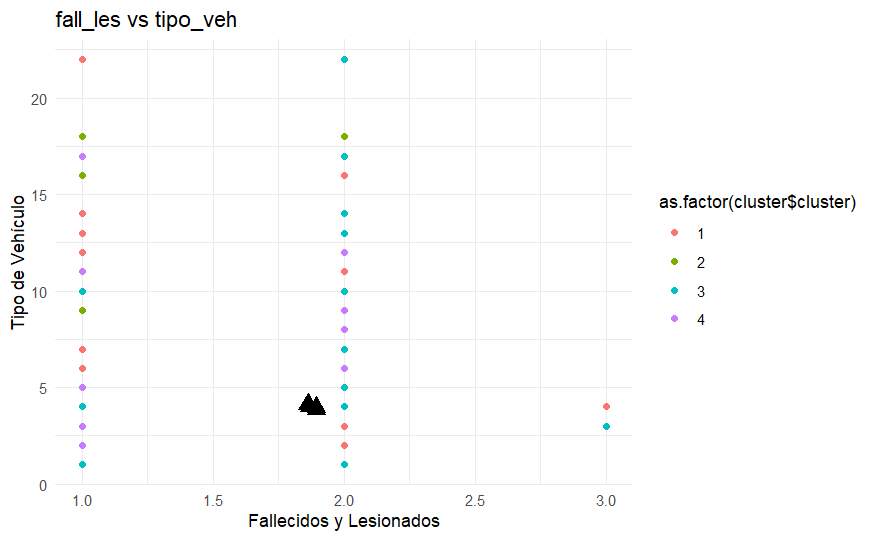

```r
cluster <- kmeans(data_fp_gua, centers = 4)
ggplot(data_fp_gua, aes(x = fall_les, y = tipo_veh, color = as.factor(cluster$cluster))) +
  geom_point() +
  geom_point(data = as.data.frame(cluster$centers),
             aes(x = fall_les, y = tipo_veh),
             color = "black", size = 4, shape = 17) +
  labs(title = "fall_les vs tipo_veh") +
  theme_minimal()
```

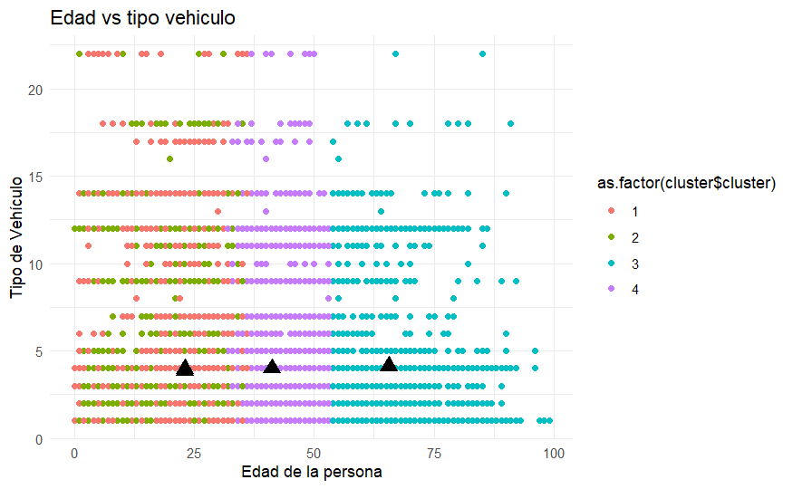

```r
cluster <- kmeans(data_fp_gua, centers = 4)
ggplot(data_fp_gua, aes(x = edad_per, y = tipo_veh, color = as.factor(cluster$cluster))) +
  geom_point() +
  geom_point(data = as.data.frame(cluster$centers),
             aes(x = edad_per, y = tipo_veh),
             color = "black", size = 4, shape = 17) +
  labs(title = "Edad vs tipo vehiculo") +
  theme_minimal()
```

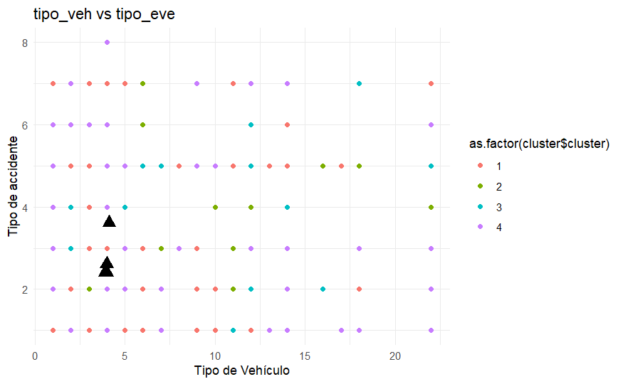

```r
cluster <- kmeans(data_fp_gua, centers = 4)
ggplot(data_fp_gua, aes(x = tipo_veh, y = tipo_eve, color = as.factor(cluster$cluster))) +
  geom_point() +
  geom_point(data = as.data.frame(cluster$centers),
             aes(x = tipo_veh, y = tipo_eve),
             color = "black", size = 4, shape = 17) +
  labs(title = "tipo_veh vs tipo_eve") +
  theme_minimal()
```

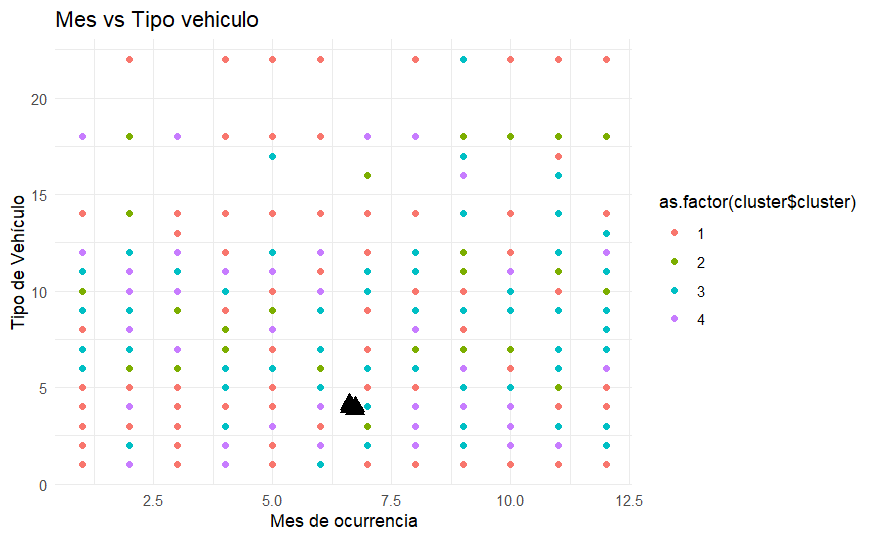

```r
cluster <- kmeans(data_fp_gua, centers = 4)
ggplot(data_fp_gua, aes(x = mes_ocu, y = tipo_veh, color = as.factor(cluster$cluster))) +
  geom_point() +
  geom_point(data = as.data.frame(cluster$centers),
             aes(x = mes_ocu, y = tipo_veh),
             color = "black", size = 4, shape = 17) +
  labs(title = "Mes vs Tipo vehiculo") +
  theme_minimal()
```

```r
set.seed(123)
kmeans_final <- kmeans(data_fp_scaled, centers = 4, nstart = 25)
```

```r
data_fp_gua_cluster <- data_fp_gua %>%
  mutate(cluster = kmeans_final$cluster)
```

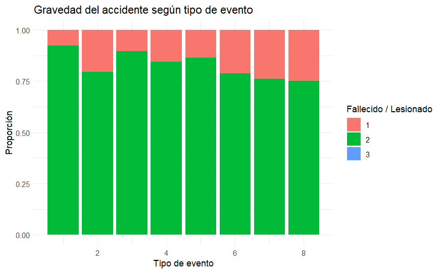

```r
ggplot(data_fp_gua_cluster, aes(x = tipo_eve, fill = as.factor(fall_les))) +
  geom_bar(position = "fill") +
  labs(
    title = "Gravedad del accidente según tipo de evento",
    x = "Tipo de evento",
    y = "Proporción",
    fill = "Fallecido / Lesionado"
  ) +
  theme_minimal()
```

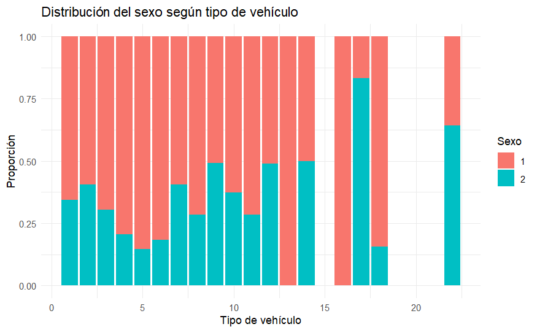

```r
ggplot(data_fp_gua_cluster, aes(x = tipo_veh, fill = as.factor(sexo_per))) +
  geom_bar(position = "fill") +
  labs(
    title = "Distribución del sexo según tipo de vehículo",
    x = "Tipo de vehículo",
    y = "Proporción",
    fill = "Sexo"
  ) +
  theme_minimal()
```

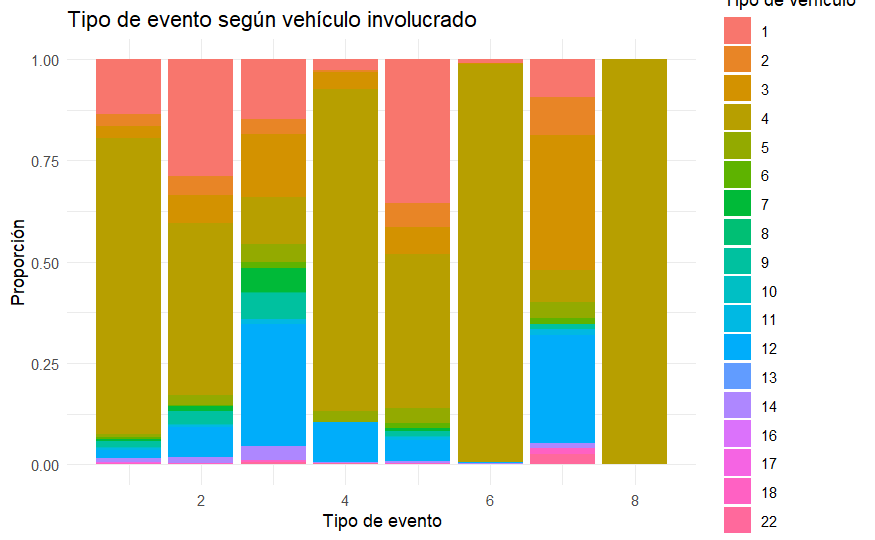

```r
ggplot(data_fp_gua_cluster, aes(x = tipo_eve, fill = as.factor(tipo_veh))) +
  geom_bar(position = "fill") +
  labs(
    title = "Tipo de evento según vehículo involucrado",
    x = "Tipo de evento",
    y = "Proporción",
    fill = "Tipo de vehículo"
  ) +
  theme_minimal()
```

```r
install.packages("combinat")
library(dplyr)
library(ggplot2)
library(combinat)

data_num <- data_fp_gua %>%
  mutate(across(everything(), ~ as.numeric(as.factor(.x)))) %>%
  mutate(cluster = kmeans_final$cluster)

# Se generan todas las combinaciones posibles de pares de variables
vars <- names(data_num)[!names(data_num) %in% "cluster"]
pairs <- combn(vars, 2, simplify = FALSE)

# Se calcula la distancia promedio entre centroides por cada par de variables
distances <- sapply(pairs, function(v) {
  df <- data_num %>% select(all_of(v), cluster)
  centroids <- df %>%
    group_by(cluster) %>%
    summarise(across(everything(), mean))

  # Matriz de distancias euclidianas entre los centroides
  d <- dist(centroids[, -1])

  mean(as.numeric(d))  # promedio de distancias
})

#Ordenar las combinaciones según la mejor separación
ranked_pairs <- tibble(
  var1 = sapply(pairs, `[`, 1),
  var2 = sapply(pairs, `[`, 2),
  mean_centroid_distance = distances
) %>%
  arrange(desc(mean_centroid_distance))

print(ranked_pairs)
```

| var1 | var2 | mean_centroid_distance |
| --- | --- | --- |
| edad_per | tipo_veh | 5.3332452 |
| tipo_veh | tipo_eve | 4.7835745 |
| fall_les | tipo_veh | 3.8777279 |
| sexo_per | tipo_veh | 3.8776358 |
| año_ocu | tipo_veh | 3.7544841 |
| mes_ocu | tipo_veh | 3.7283640 |
| día_ocu | tipo_veh | 3.6772571 |
| edad_per | tipo_eve | 3.3956039 |
| año_ocu | edad_per | 2.8199187 |
| edad_per | fall_les | 2.7822424 |

[output cut: 18 more lines]

```r
NA
NA
```